# Do Millennials care about politics?

Xinyuan Peng

2020/9/23

#### GR5243

#### Project1

# Introduction

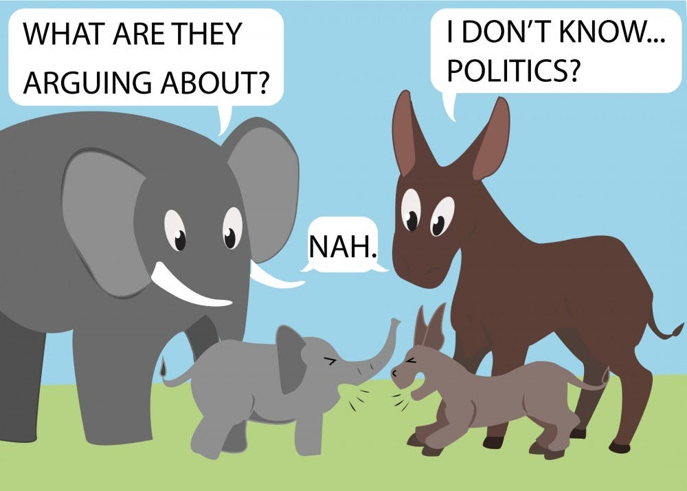

*“When It Comes to Politics, Do Millennials Care About Anything?”*, the Article posted on the Atlantic caught our attention. Millennials, who were born between 1981 and 1996, have been labeled with countless negative qualities. One main criticism of millennials is their lack of political concern. However, is it true to label them being indifferent about politics? We are going to testify the argument based on the data from 2020 Exploratory Testing Survey.

The survey content was shaped to a significant degree by ideas offered by the ANES user community through public solicitations and by members of the ANES national advisory board. Additional questions were included to capture changes in the political environment and recent developments in social science research. The questionnaire includes questions about voting behavior, candidate traits, political engagement, ideological orientations, racial identity and stereotyping, and many topical issues including #MeToo, immigration, impeachment, and the coronavirus pandemic.

We are going to focus on the following 3 aspects:

1. Registration rate comparation
2. How often do they follow politics
3. Participantion rate of political activities comparation

# Sample Population vs. True Population

Before we start analyzing, let’s take a look at the dataset, especially the birth year distribution because our analysis will base on respondents’ birth year and detect the differences among different ages.

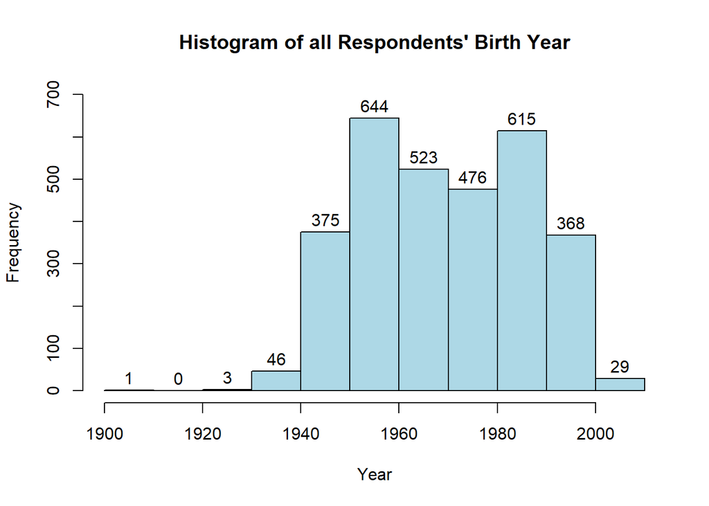

In addition, we have 820 out of 3080 respondents(26.6%) are Millennials, which is consistent with the true population distribution. Therefore, the following analysis based on the 2020 Exploratory Testing Survey provides a reference to the reality.

# 1. Registration Rate Comparation

First, we will compare respondents’ registration rate.

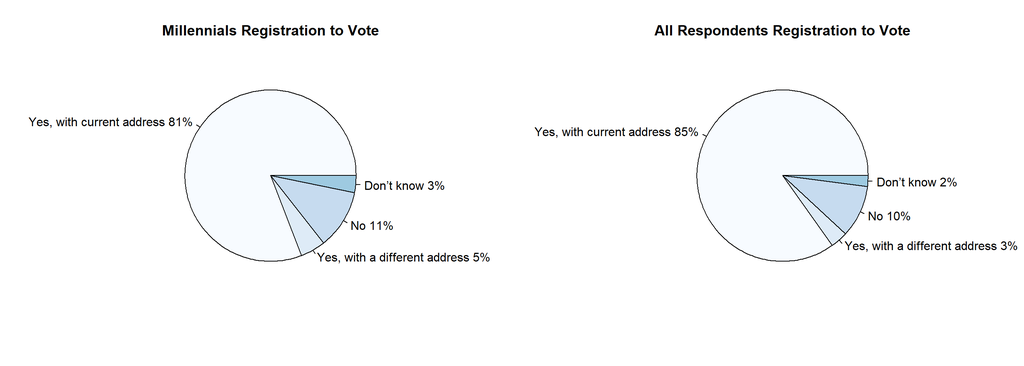

By contrast, 86% of Millennials have registered, which is lower than overall condition(88%). It is worth noting that there are 5% of Millennials have registered with a different address, which is higher than overall condition(3%). The reason might be that, more Milliennials are working or studying away from home.

**Therefore, Millennials have a slightly smaller proportion of registration than all respondents, which is insufficient to say that they are lack of political concerns.**

# 2. How often do they follow politics

Second, we will compare respodents’ frequency of following politics

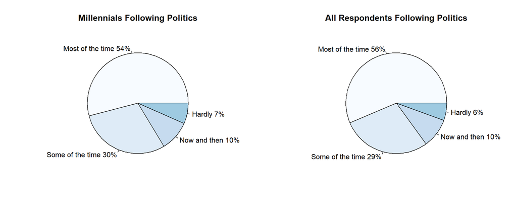

By contrast, 54% of Millennials follow politics most of the time, which is lower than overall condition(56%). But 30% of Millennials follow politics some of the time, which is higher than overall condition(29%).

**Therefore, Millennials have nearly the same frequency of following politics.**

# 3. Participantion rate of political activities

Third, we will compare respodents’ participantion rate of 8 kinds of political activities during the past 12 months. Here are the explainations of 8 kinds of political activities:

- meeting: Attended a meeting to talk about political or social concerns
- moneyorg: Given money to an organization concerned with a political or social issue
- protest: Joined in a protest march, rally, or demonstration
- online: Posted a message or comment online about a political issue or campaign
- persuade: Tried to persuade anyone to vote one way or another
- button: Worn a campaign button, put a sticker on your car, or placed a sign in your window or in front of your house
- moneycand: Given money to any candidate running for public office, any political party, or any other group that supported or opposed candidates
- argument: Gotten into a political argument with someone
- particip_none: None of these

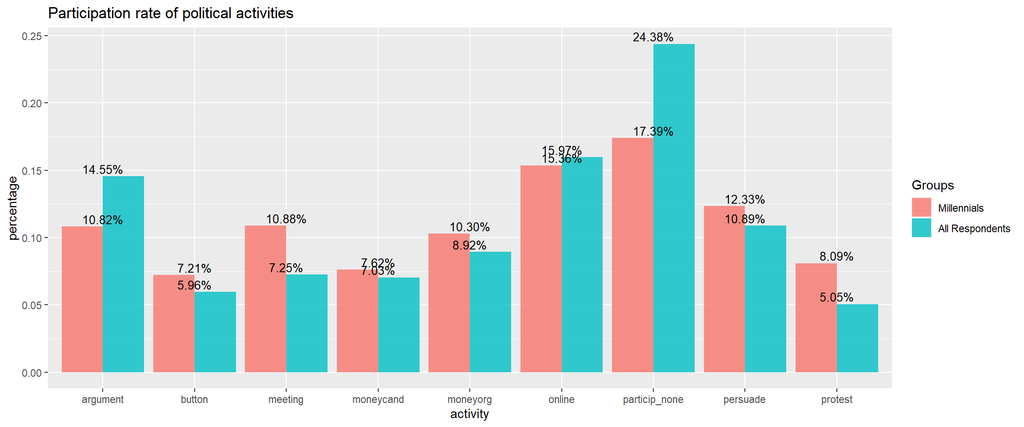

By contrast, around 83% of Millennials participated in at least one kind of political activities, which is much higher than overall condition(76%). Except argument and online, Millennials have higher participation rate in other 6 kinds of activities. It is worth noting that Millennials participation rates are very different from overall conditions in argument, meeting, and protest: Millennials are relatively more often to attended a meeting to talk about political or social concerns; Millennials are relatively seldom to get into a political argument with someone; Millennials are relatively more often to join in a protest march, rally, or demonstration.

# Conclusion

Millennials have a slightly lower registration rate, but they share a similar frequency with all respondents of following politics. In addtion, they have a higher participation rate in political activities, especially in attending meetings to talk about politics and joining in protest marches.

**Therefore, the argument that ‘Millennials are indifferent in politics’ is inconsistent with our analysis above.**